# Practical Machine Learning - Prediction Project

JDP

Tuesday, April 14, 2015

# Find Best Prediction Model for Personal Activity

## Background

Using devices such as Jawbone Up, Nike FuelBand, and Fitbit it is now possible to collect a large amount of data about personal activity relatively inexpensively. These type of devices are part of the quantified self movement - a group of enthusiasts who take measurements about themselves regularly to improve their health, to find patterns in their behavior, or because they are tech geeks. One thing that people regularly do is quantify how much of a particular activity they do, but they rarely quantify how well they do it. In this project, your goal will be to use data from accelerometers on the belt, forearm, arm, and dumbell of 6 participants. They were asked to perform barbell lifts correctly and incorrectly in 5 different ways. More information is available from the website here: http://groupware.les.inf.puc-rio.br/har (please check section on the Weight Lifting Exercise Dataset).

## Data source

The training data for this project was downloaded from: https://d396qusza40orc.cloudfront.net/predmachlearn/pml-training.csv The test data was downloaded from: https://d396qusza40orc.cloudfront.net/predmachlearn/pml-testing.csv The data for this project came from this source: http://groupware.les.inf.puc-rio.br/har.

## Prepare datasets

Load the training data into a data table/frame.

```r
library(data.table)
setwd("C:/Users/Desmond/Documents/PML")
dat <- fread("pml-training.csv")
dim(dat)
```

```
## [1] 19622   160
```

Load the testing data into a data table/frame.

```r
testdat <- fread("pml-testing.csv")
dim(testdat)
```

```
## [1]  20 160
```

Belt, arm, dumbbell, and forearm variables without missing values in the train (and test) dataset are chosen as predictor candidates.

```r
isAnyMissing <- sapply(dat, function (x) any(is.na(x) | x == ""))
isPredictor <- !isAnyMissing & grepl("belt|[^(fore)]arm|dumbbell|forearm", names(isAnyMissing))
predCandidates <- names(isAnyMissing)[isPredictor]
```

Subset the original dataset to include only the predictor candidates and the outcome/response variable, classe.

```r
varsToInclude <- c("classe", predCandidates)
subdat <- dat[, varsToInclude, with = FALSE]
dim(subdat)
```

```
## [1] 19622    53
```

```r
names(subdat)
```

```
##  [1] "classe"               "roll_belt"            "pitch_belt"
##  [4] "yaw_belt"             "total_accel_belt"     "gyros_belt_x"
##  [7] "gyros_belt_y"         "gyros_belt_z"         "accel_belt_x"
## [10] "accel_belt_y"         "accel_belt_z"         "magnet_belt_x"
## [13] "magnet_belt_y"        "magnet_belt_z"        "roll_arm"
## [16] "pitch_arm"            "yaw_arm"              "total_accel_arm"
## [19] "gyros_arm_x"          "gyros_arm_y"          "gyros_arm_z"
## [22] "accel_arm_x"          "accel_arm_y"          "accel_arm_z"
## [25] "magnet_arm_x"         "magnet_arm_y"         "magnet_arm_z"
## [28] "roll_dumbbell"        "pitch_dumbbell"       "yaw_dumbbell"
## [31] "total_accel_dumbbell" "gyros_dumbbell_x"     "gyros_dumbbell_y"
## [34] "gyros_dumbbell_z"     "accel_dumbbell_x"     "accel_dumbbell_y"
## [37] "accel_dumbbell_z"     "magnet_dumbbell_x"    "magnet_dumbbell_y"
## [40] "magnet_dumbbell_z"    "roll_forearm"         "pitch_forearm"
## [43] "yaw_forearm"          "total_accel_forearm"  "gyros_forearm_x"
## [46] "gyros_forearm_y"      "gyros_forearm_z"      "accel_forearm_x"
## [49] "accel_forearm_y"      "accel_forearm_z"      "magnet_forearm_x"
## [52] "magnet_forearm_y"     "magnet_forearm_z"
```

Make classe into a factor (and find count for each classe value).

```r
subdat <- subdat[, classe := factor(subdat[, classe])]
subdat[, .N, classe]
```

```
##    classe    N
## 1:      A 5580
## 2:      B 3797
## 3:      C 3422
## 4:      D 3216
## 5:      E 3607
```

## Split the training dataset

The subsetted dataset was then divided into two partitions, a training partition (70%) and a probing partition (30%). It creates a list because by default, value of parameter *list* is *TRUE*.

```r
library(caret)
seed <- as.numeric(as.Date("2015-04-14"))
set.seed(seed)
inTrain <- createDataPartition(subdat$classe, p = 0.7)
datTrain <- subdat[inTrain[[1]]]
datProbe <- subdat[-inTrain[[1]]]
```

## Transform data using centering and scaling

Preprocess the prediction variables by centering and scaling.

```r
X <- datTrain[, predCandidates, with = FALSE]
preProc <- preProcess(X)
preProc
```

```
##
## Call:
## preProcess.default(x = X)
##
## Created from 11776 samples and 52 variables
## Pre-processing: centered, scaled
```

```r
XCS <- predict(preProc, X)
datTrainCS <- cbind(classe = datTrain[, classe], XCS)
```

Apply the centering and scaling to the probing dataset.

```r
X <- datProbe[, predCandidates, with = FALSE]
XCS <- predict(preProc, X)
datProbeCS <- cbind(classe = datProbe[, classe], XCS)
```

Check for variables with near zero variance.

```r
NZV <- nearZeroVar(datTrainCS, saveMetrics = TRUE)
if (any(NZV$nzv)) NZV else print("No variables with near zero variance")
```

```
## [1] "No variables with near zero variance"
```

## Draw exploratory graphs

Examine various groups of (centered and scaled) prediction variables using [violin plots](http://en.wikipedia.org/wiki/Violin_plot) (combination of box plots and kernel density plots).

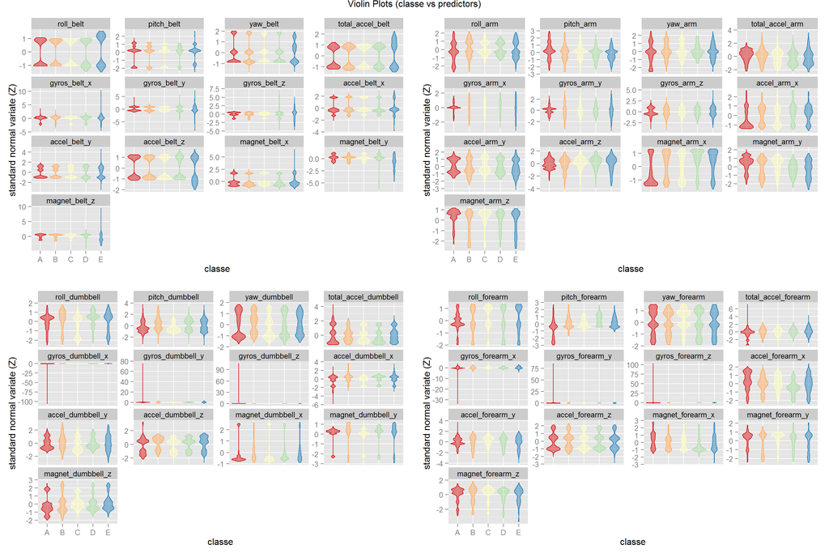

```r
# create a function for violin plot
violinGroup <- function (data, regex) {
  col <- grep(regex, names(data))
  col <- c(col, which(names(data) == "classe"))
  library(reshape2)
  n <- nrow(data)
  datMelted <- melt(data[, col, with = FALSE][, rownum := seq(1, n)],
                    id.vars = c("rownum", "classe"))
  library(ggplot2)
  ggplot(datMelted, aes(x = classe, y = value)) +
    geom_violin(aes(color = classe, fill = classe), alpha = 1/2) +
    facet_wrap(~ variable, scale = "free_y") +
    scale_color_brewer(palette = "Spectral") +
    scale_fill_brewer(palette = "Spectral") +
    labs(x = "classe", y = "standard normal variate (Z)") +
    theme(legend.position = "none")
}

# make violin plots
vg11 <- violinGroup(data.table(datTrainCS), "belt")
vg12 <- violinGroup(data.table(datTrainCS), "[^(fore)]arm")
vg21 <- violinGroup(data.table(datTrainCS), "dumbbell")
vg22 <- violinGroup(data.table(datTrainCS), "forearm")

# draw the plots in a grid
library(gridExtra)
grid.arrange(vg11, vg12, vg21, vg22, nrow = 2, ncol = 2,
             widths = c(5), heights = c(10),
             main = "Violin Plots (classe vs predictors)")
```

Variances are high in classe E for gyros.belt.x, gyros.belt.z, magnet.belt.z, and gyros.arm.z whereas outliers exist in classe A for gyros.forearm.x, gyros.forearm.y and gyros.forearm.z as well as for gyros.dumbbell.x, gyros.dumbbell.y and gyros.dumbbell.z. Please note that y-axes scales (for Z values) are different for each graph.

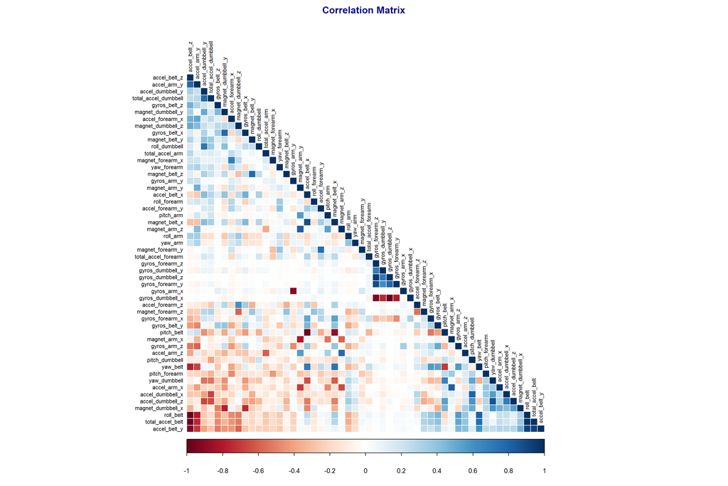

```r
library(corrplot)
corMat <- cor(as.data.frame.matrix(datTrain)[, -1])
corrplot(corMat, order = "FPC", method = "color", type = "lower",
         title = "Correlation Matrix", mar = c(0, 0, 2, 0),
         tl.cex = 0.7, tl.col = rgb(0, 0, 0), col.main = "darkblue")
```

The above left triangular matrix shows the correlation between pairs of the predictors in our training dataset. The dark blue and dark red squares indicate high positive and high negative correlations respectively. These can be explored further using principal component analysis.

## Train prediction models and compute confusion matrices to estimate out of sample error rates

Let us now fit classification and regression tree model, linear discriminant analysis model and random forest model (with cross validation) and then find the best one. I have not fit generalized linear model as classe is a factor variable (and it will have to be converted to numeric first) and will give meaningless predictions as decimal numbers (see Quiz 3 - Q3).

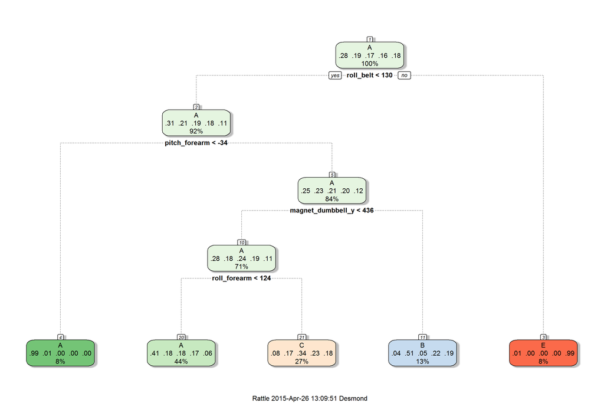

```r
### Classification & regression tree (CART/C&RT) model
cart.fit <- train(classe ~ ., method = "rpart", data = datTrain,
                  trControl = trainControl(method = "cv", number = 10))
# plot prettier classification tree
rattle::fancyRpartPlot(cart.fit$finalModel)
```

```r
# predict outcomes for probe data set using CART model
pcart <- predict(cart.fit, newdata = datProbe)
# find confusion matrix
cmcart <- confusionMatrix(pcart, datProbe$classe)
cmcart
```

```
## Confusion Matrix and Statistics
##
##           Reference
## Prediction    A    B    C    D    E
##          A 2028  631  658  571  198
##          B   41  513   35  244  209
##          C  158  374  675  471  392
##          D    0    0    0    0    0
##          E    5    0    0    0  643
##
## Overall Statistics
##
##                Accuracy : 0.4918
##                  95% CI : (0.4807, 0.503)
##     No Information Rate : 0.2845
##     P-Value [Acc > NIR] : < 2.2e-16
##
##                   Kappa : 0.3357
##  Mcnemar's Test P-Value : NA
##
## Statistics by Class:
##
##                      Class: A Class: B Class: C Class: D Class: E
## Sensitivity            0.9086  0.33794  0.49342   0.0000  0.44591
## Specificity            0.6334  0.91640  0.78466   1.0000  0.99922
## Pos Pred Value         0.4963  0.49232  0.32609      NaN  0.99228
## Neg Pred Value         0.9457  0.85229  0.88002   0.8361  0.88900
## Prevalence             0.2845  0.19347  0.17436   0.1639  0.18379
## Detection Rate         0.2585  0.06538  0.08603   0.0000  0.08195
## Detection Prevalence   0.5208  0.13281  0.26383   0.0000  0.08259
## Balanced Accuracy      0.7710  0.62717  0.63904   0.5000  0.72256
```

```r
save(cart.fit, file = "cart.RData")
```

If we use datTrainCS or preProcess to center & scale, then conditions on tree branches are Z values which may be difficult to interpret.  
Accuracy of CART model is 49.18%.

```r
### Linear discriminant analysis
lda.fit <- train(classe ~ ., method = "lda", data = datTrainCS,
                 trControl = trainControl(method = "cv", number = 10))
# predict outcomes for probe data set using LDA model
plda <- predict(lda.fit, datProbeCS)
# find confusion matrix
cmlda <- confusionMatrix(plda, datProbeCS$classe)
cmlda
```

```
## Confusion Matrix and Statistics
##
##           Reference
## Prediction    A    B    C    D    E
##          A 1837  250  121   74   56
##          B   58  940  135   66  280
##          C  178  197  899  160  126
##          D  147   54  176  941  139
##          E   12   77   37   45  841
##
## Overall Statistics
##
##                Accuracy : 0.6956
##                  95% CI : (0.6853, 0.7058)
##     No Information Rate : 0.2845
##     P-Value [Acc > NIR] : < 2.2e-16
##
##                   Kappa : 0.6147
##  Mcnemar's Test P-Value : < 2.2e-16
##
## Statistics by Class:
##
##                      Class: A Class: B Class: C Class: D Class: E
## Sensitivity            0.8230   0.6192   0.6572   0.7317   0.5832
## Specificity            0.9108   0.9148   0.8980   0.9213   0.9733
## Pos Pred Value         0.7857   0.6356   0.5763   0.6458   0.8310
## Neg Pred Value         0.9283   0.9092   0.9254   0.9460   0.9121
## Prevalence             0.2845   0.1935   0.1744   0.1639   0.1838
## Detection Rate         0.2341   0.1198   0.1146   0.1199   0.1072
## Detection Prevalence   0.2980   0.1885   0.1988   0.1857   0.1290
## Balanced Accuracy      0.8669   0.7670   0.7776   0.8265   0.7783
```

```r
save(lda.fit, file = "lda.RData")
```

Accuracy of LDA model is 69.56%.

**Note:** Cross validation is inherently conducted by random forest models.  
http://www.stat.berkeley.edu/~breiman/RandomForests/cc_home.htm#ooberr  
http://stackoverflow.com/questions/19760169/how-to-perform-random-forest-cross-validation-in-r

```r
### Random forests
# set up for parallel clusters
library(parallel)
library(doParallel)
cl <- makeCluster(detectCores() - 1)
registerDoParallel(cl)
# fit a random forest
library(randomForest)
set.seed(123456)
rf.fit <- randomForest(classe ~ ., data = datTrain, ntree = 500, mtry = 20)
stopCluster(cl)
# predict outcomes for probe data set using random forest model
prf <- predict(rf.fit, datProbe)
# find confusion matrix
cmrf <- confusionMatrix(prf, datProbe$classe)
cmrf
```

```
## Confusion Matrix and Statistics
##
##           Reference
## Prediction    A    B    C    D    E
##          A 2232   10    0    0    0
##          B    0 1497    7    0    0
##          C    0   11 1358   20    3
##          D    0    0    3 1265    4
##          E    0    0    0    1 1435
##
## Overall Statistics
##
##                Accuracy : 0.9925
##                  95% CI : (0.9903, 0.9943)
##     No Information Rate : 0.2845
##     P-Value [Acc > NIR] : < 2.2e-16
##
##                   Kappa : 0.9905
##  Mcnemar's Test P-Value : NA
##
## Statistics by Class:
##
##                      Class: A Class: B Class: C Class: D Class: E
## Sensitivity            1.0000   0.9862   0.9927   0.9837   0.9951
## Specificity            0.9982   0.9989   0.9948   0.9989   0.9998
## Pos Pred Value         0.9955   0.9953   0.9756   0.9945   0.9993
## Neg Pred Value         1.0000   0.9967   0.9985   0.9968   0.9989
## Prevalence             0.2845   0.1935   0.1744   0.1639   0.1838
## Detection Rate         0.2845   0.1908   0.1731   0.1612   0.1829
## Detection Prevalence   0.2858   0.1917   0.1774   0.1621   0.1830
## Balanced Accuracy      0.9991   0.9925   0.9937   0.9913   0.9975
```

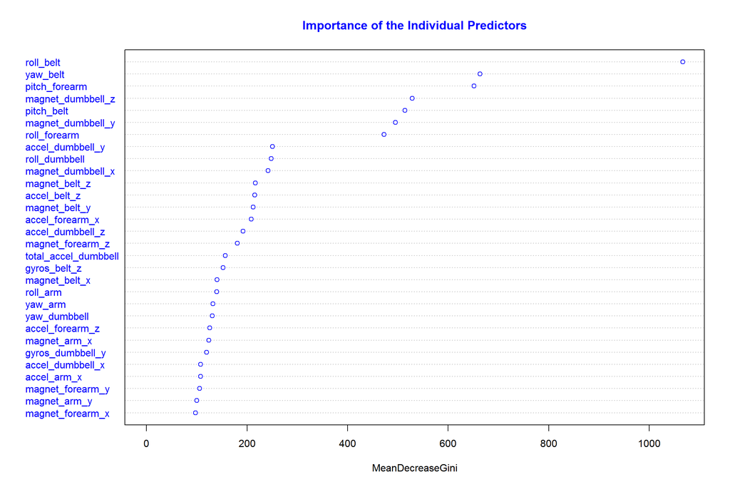

```r
# plot importance of predictors
varImpPlot(rf.fit, sort = TRUE, type = 2, col = 4, cex = 1, col.main = "blue",
           main = "Importance of the Individual Predictors")
```

```r
save(rf.fit, file = "rf.RData")
```

Accuracy of RF model is 99.25%. Let us try RF with only 7 most important predictors (see graph above).

```r
cl <- makeCluster(detectCores() - 1)
registerDoParallel(cl)
# fit a random forest
set.seed(123456)
rf7.fit <- randomForest(classe ~ roll_belt + yaw_belt + pitch_forearm +
        magnet_dumbbell_z + pitch_belt + magnet_dumbbell_y + roll_forearm,
        data = datTrain, ntree = 500)
stopCluster(cl)
# predict outcomes for probe data set using random forest model
prf7 <- predict(rf7.fit, datProbe)
# find confusion matrix
cmrf7 <- confusionMatrix(prf7, datProbe$classe)
cmrf7
```

[output not shown]

```r
save(rf7.fit, file = "rf7.RData")
```

Accuracy of RF model with only 7 most important predictors is 98.76%.

Using random forest model, the error rate estimated using the probing data set is the smallest. The expected **out-of-sample (OOB) error rate** is estimated to be 0.75%. Hence we will use RF model `rf.fit` on our test data set.

## Use best model to predict outcomes on the test dataset

Get predictions and evaluate.

```r
subtestdat <- testdat[, predCandidates, with = FALSE]
hat <- predict(rf.fit, subtestdat)
subtestdat <- cbind(hat , subtestdat)
hat
```

```
##  1  2  3  4  5  6  7  8  9 10 11 12 13 14 15 16 17 18 19 20
##  B  A  B  A  A  E  D  B  A  A  B  C  B  A  E  E  A  B  B  B
## Levels: A B C D E
```

**NOTE:** We get the same values for `hat` vector (classification of outcomes) if we use `rf7.fit` model.

## Submission to Coursera

Write submission files to “PML - Prediction Project Writeup files/answers” folder.

```r
pml_write_files = function(x){
  n = length(x)
  path <- "PML_-_Prediction_Project_Writeup_files/answers"
  if (!file.exists(path))
      dir.create(path)
  for(i in 1:n){
    filename = paste0("problem_id_",i,".txt")
    write.table(x[i], file = file.path(path, filename), quote = FALSE,
                row.names = FALSE, col.names = FALSE)
  }
}
pml_write_files(hat)
```

The predictions produced by the RF models were marked as 100% correct on first submission when the files created above were submitted to assignment submission page on Coursera website.

## Conclusion

Random forest models were the best for accuracy. Model `rf.fit` was 99.25% accurate while model `rf7.fit` (using only 7 predictors) was 98.76% accurate in classifying outcomes. These 7 predictors also do not have issues mentioned in violin plots above.

All models ran quickly. The two random forest models ran within 2.5 minutes (`rf7.fit` ran within 20 seconds). The key was to use `library(randomForest)` instead of `library(caret)` for RF models.

## Bibliography

1. Groupware@LES. *Human Activity Recognition*. Retrieved on 7th Apr 2015 from http://groupware.les.inf.puc-rio.br/har.
2. Velloso, E., Bulling, A., Gellersen, H., Ugulino, W., Fuks, H. *Qualitative Activity Recognition of Weight Lifting Exercises*. Proceedings of 4th International Conference in Cooperation with SIGCHI (Augmented Human ’13). Stuttgart, Germany: ACM SIGCHI, 2013.
3. Wikipedia. *Violin plot*. Retrieved on 10th Apr 2015 from http://en.wikipedia.org/wiki/Violin_plot.